# R Track Week 4 Assignment

Kumudini Bhave

August 6, 2016

# **Mars Crater Study**

## Summary

This is an R Markdown document for providing documentation for performing **Data Exploration of the Mars Craters DataSet**

Attempted to study data that comprises of various Craters on Mars with recorded information of the Latitude, Longitude, Circular Diameter, Depth of rim floor, Different Morphological data, Number of Layers The Mars Crater Study aims to focus on the **Circular Diameter** as well as **Depth of rim floor** and **Number of Layers**.

Following attributes are extracted and mapped to the explicit values for the observations selected as above, from the **Mars Craters DataSet**:

- **DIAM_CIRCLE_IMAGE** : Diameter from a non-linear least-squares circle fit to the vertices selected to manually identify the crater rim. Units are km.
- **DEPTH_RIMFLOOR_TOPOG** : Defined as DEPTH_RIM_TOPOG - DEPTH_FLOOR_TOPOG Where - **DEPTH_RIM_TOPOG** : Average elevation of each of the manually determined N points along the crater rim. Points are selected as relative topographic highs under the assumption they are the least eroded so most original points along the rim. Units are km. - **DEPTH_FLOOR_TOPOG** : Average elevation of each of the manually determined N points inside the crater floor. Points were chosen as the lowest elevation that did not include visible embedded craters. Units are km.
- **NUMBER_LAYERS** : The maximum number of cohesive layers in any azimuthal direction that could be reliably identified.

## R Code For Data Exploration and Transformation Of Mars Craters Dataset

### Extracting Raw Data From GitHub Data File And Reading In CSV Format

Loading RCurl package to help scrape data from web (stored on GitHub).

```r
knitr::opts_chunk$set(message = FALSE, echo = TRUE)


library(RCurl)
library(ggplot2)
library(gcookbook)
library(DT)
```

Extracting data from GitHub Data file, and reading the same in CSV format

```r
data.giturl <- "https://raw.githubusercontent.com/DataDriven-MSDA/RProgramming/master/marscrater_pds.csv"
mars.gitdata <- getURL(data.giturl)
mars.gitdata.csv <- read.csv2(text = mars.gitdata, header = T, sep = ",", stringsAsFactors = FALSE)
```

### Extracting Select Attributes For Mars Craters Dataset Study

Subsetting the data based on Circular Diamater, Depth and Number of Layers

```r
marscrater.datastudy <- subset(mars.gitdata.csv, (NUMBER_LAYERS > 0 & DEPTH_RIMFLOOR_TOPOG >
    1 & DIAM_CIRCLE_IMAGE > 10), na.rm = T, select = c(DIAM_CIRCLE_IMAGE, DEPTH_RIMFLOOR_TOPOG,
    NUMBER_LAYERS))


# Verifying the number of attributes

cat("Number of attributes for study : ", length(marscrater.datastudy))
```

```
## Number of attributes for study :  3
```

```r
# Verifying the number of observations selected
cat("Number of observations for study : ", nrow(marscrater.datastudy))
```

```
## Number of observations for study :  1794
```

### Data For Mars Craters Dataset Study

```r
datatable(marscrater.datastudy, options = list(searching = FALSE, pageLength = 5,
    lengthMenu = c(5, 10, 15, 20)))
```

|  | DIAM_CIRCLE_IMAGE | DEPTH_RIMFLOOR_TOPOG | NUMBER_LAYERS |
| --- | --- | --- | --- |
| 2 | 82.02 | 1.97 | 3 |
| 21 | 45.71 | 1.86 | 2 |
| 26 | 39.51 | 2.08 | 1 |
| 27 | 36.85 | 1.98 | 4 |
| 28 | 36.41 | 1.9 | 3 |
| 29 | 36.28 | 1.41 | 1 |
| 40 | 29.46 | 1.77 | 2 |
| 41 | 28.45 | 1.41 | 3 |
| 48 | 27.23 | 1.85 | 2 |
| 52 | 26.6 | 1.32 | 3 |

[output cut: 1784 more lines]

### Plotting a Histogram based on Number of Layers in the Crater

Plotting Histograms based on continuous variables, treating Number of Layers as a continuous variable. IT plots the count for each number of layer.

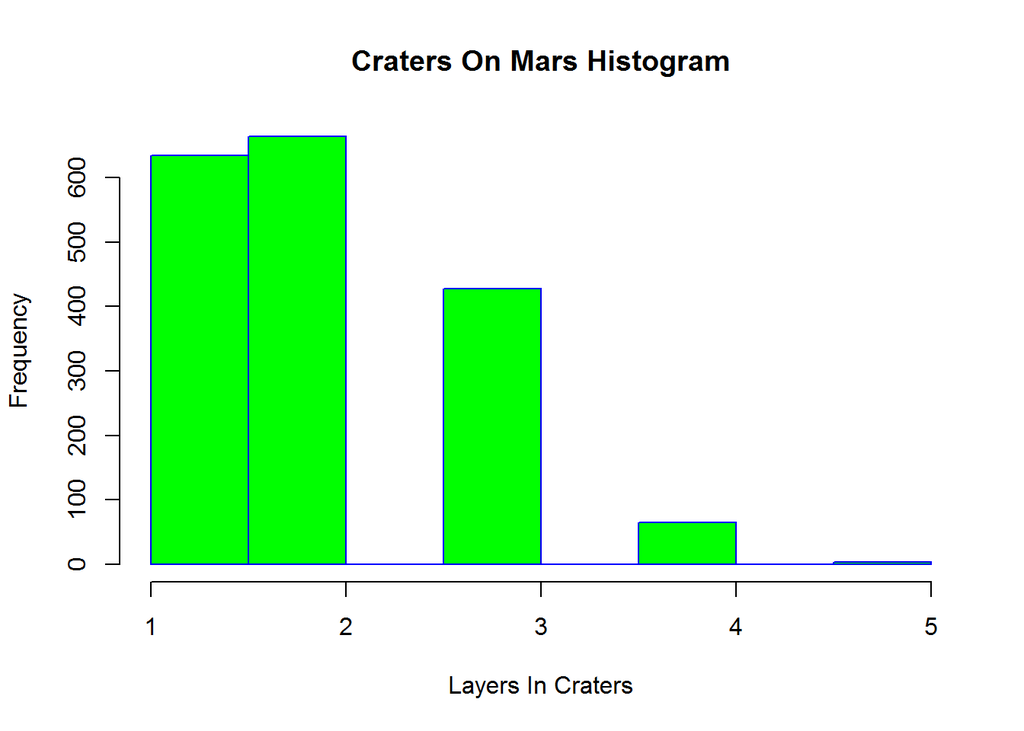

```r
marscrater.datastudy$NUMBER_LAYERS <- as.numeric(marscrater.datastudy$NUMBER_LAYERS)

hist(marscrater.datastudy$NUMBER_LAYERS, main = "Craters On Mars Histogram", xlab = "Layers In Craters",
    border = "blue", col = "green")
```

A densisty plot can also be achieved by following.

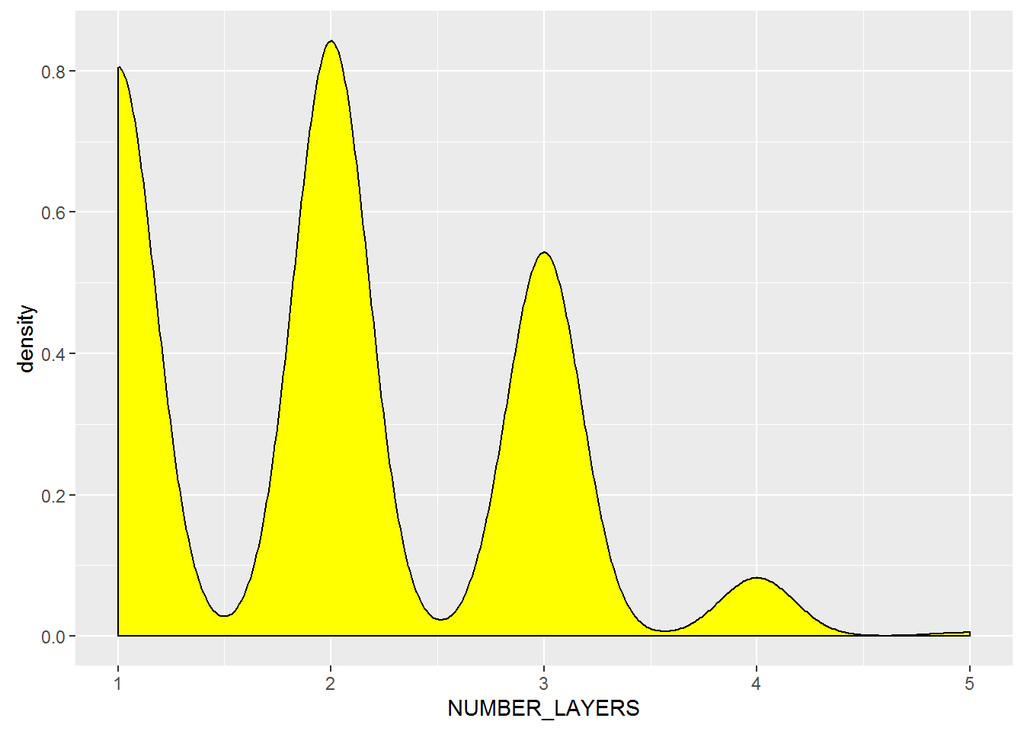

```r
ggplot(data = marscrater.datastudy) + geom_density(aes(x = NUMBER_LAYERS), fill = "yellow")
```

Plotting a histogram with ggplot function

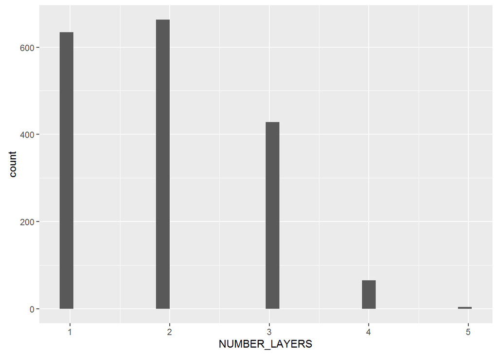

```r
ggplot(data = marscrater.datastudy) + geom_histogram(aes(x = NUMBER_LAYERS))
```

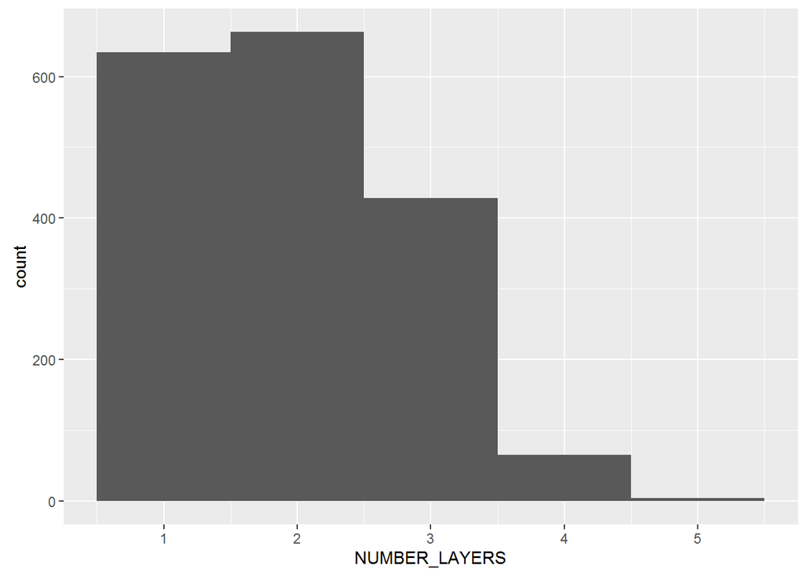

```r
ggplot(marscrater.datastudy, aes(x = NUMBER_LAYERS)) + geom_histogram(binwidth = 1)
```

### Plotting Scatter Plots

```r
marscrater.datastudy$DEPTH_RIMFLOOR_TOPOG <- as.numeric(marscrater.datastudy$DEPTH_RIMFLOOR_TOPOG)
marscrater.datastudy$DIAM_CIRCLE_IMAGE <- as.numeric(marscrater.datastudy$DIAM_CIRCLE_IMAGE)

marscrater.datastudy$NUMBER_LAYERS <- as.character(marscrater.datastudy$NUMBER_LAYERS)
```

#### Plotting Simple Scatter Plot

Plotting a simple scatter plot with grayscale / monochrome

Plotting simple scatter plot with base plot function

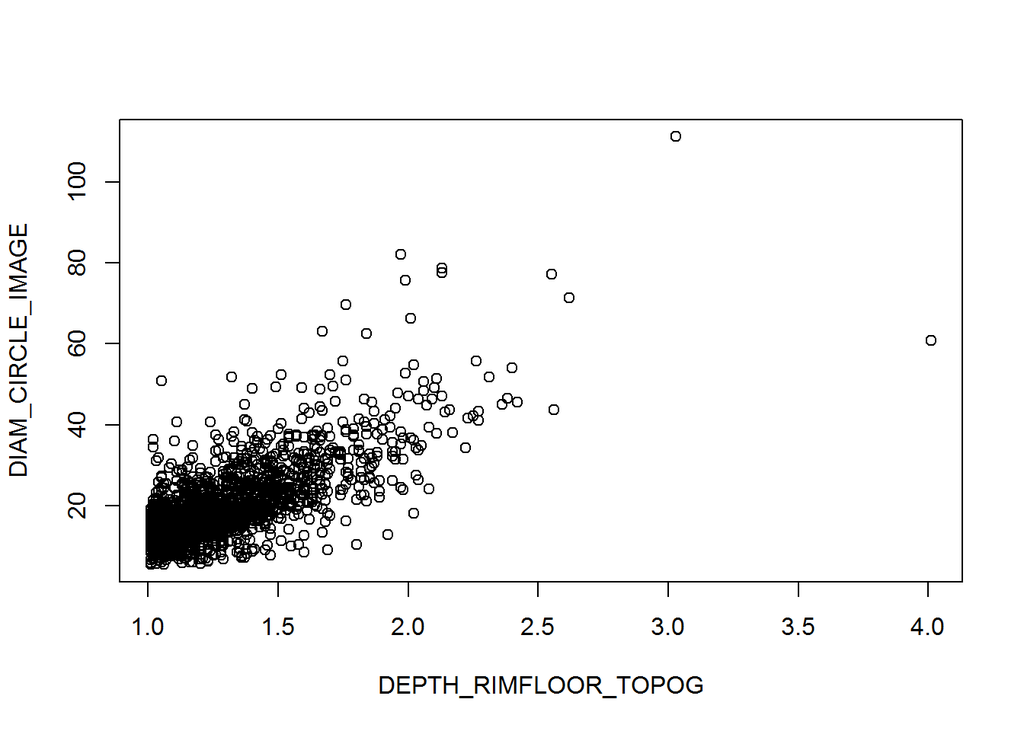

```r
plot(DIAM_CIRCLE_IMAGE ~ DEPTH_RIMFLOOR_TOPOG, data = marscrater.datastudy)
```

Plotting simple scatter plot with ggplot function

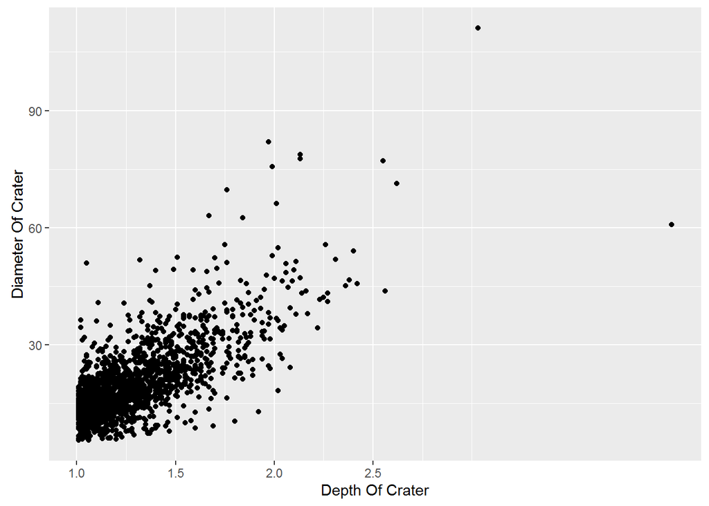

```r
ggplot(marscrater.datastudy, aes(x = DEPTH_RIMFLOOR_TOPOG, y = DIAM_CIRCLE_IMAGE)) +
    geom_point() + scale_x_continuous(name = "Depth Of Crater", breaks = c(0, 0.5,
    1, 1.5, 2, 2.5)) + scale_y_continuous(name = "Diameter Of Crater", breaks = c(30,
    60, 90, 120, 150))
```

#### Plotting Scatter Plot based on Continuous Variables of Circular Diamater , Depth Of Crater and Discrete Variable of Number of Layers in the Crater With Aesthetics of Shape And Color to Distinguish

This divides the data with different shapes and color for categorical variable of **Number Of Layers**

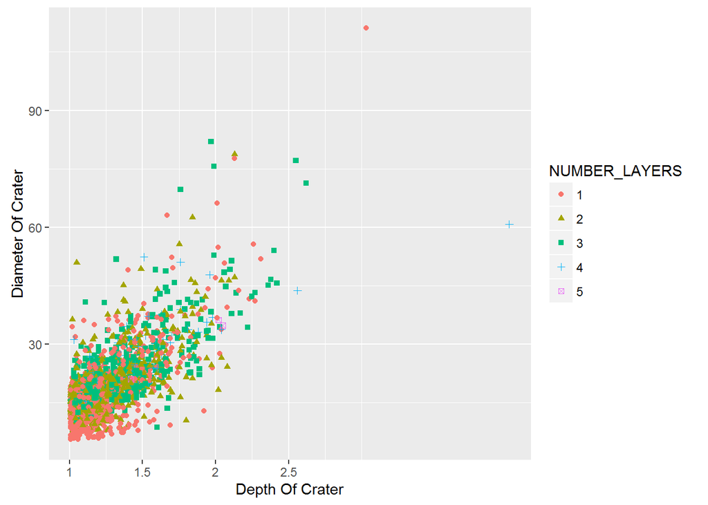

```r
ggplot(marscrater.datastudy, aes(x = (DEPTH_RIMFLOOR_TOPOG), y = (DIAM_CIRCLE_IMAGE),
    shape = NUMBER_LAYERS, colour = NUMBER_LAYERS)) + geom_point() + scale_x_continuous(name = "Depth Of Crater",
    breaks = seq(0, 2.5, 0.5), labels = seq(0, 2.5, 0.5)) + scale_y_continuous(name = "Diameter Of Crater",
    breaks = seq(0, 150, 30), labels = seq(0, 150, 30))
```

This can also be achieved by setting a base variable to the basic structure/ parameters of the scatter plot and adding enhacements to the base variable We find the same results.

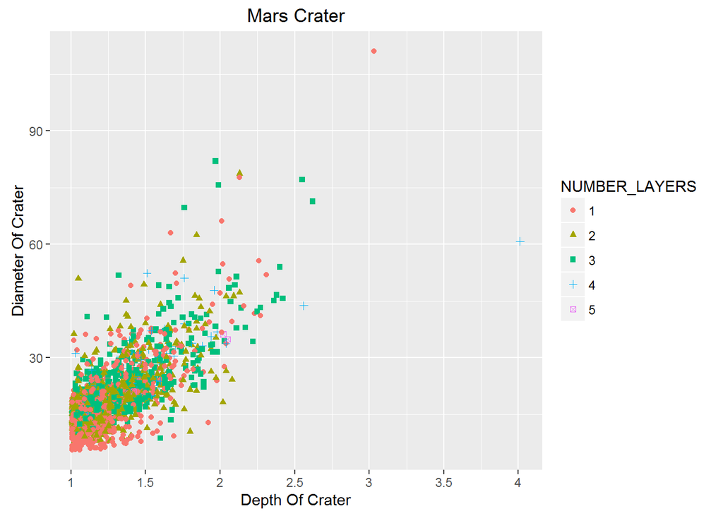

```r
craterplot <- ggplot(marscrater.datastudy, aes(x = (DEPTH_RIMFLOOR_TOPOG), y = (DIAM_CIRCLE_IMAGE),
    shape = NUMBER_LAYERS, colour = NUMBER_LAYERS))
craterplot + geom_point() + scale_x_continuous(name = "Depth Of Crater", breaks = seq(0,
    4, 0.5), labels = seq(0, 4, 0.5)) + scale_y_continuous(name = "Diameter Of Crater",
    breaks = seq(0, 100, 30), labels = seq(0, 100, 30)) + ggtitle("Mars Crater")
```

#### Plotting Scatter Plot With Facet Wrap based on Continuous Variables of Circular Diamater , Depth Of Crater and Discrete Variable of Number of Layers in the Crater With Aesthetics of Shape And Color to Distinguish

This creates **faceted scatter plots** for different levels of **Number Of Layers** and makes a separate pane for each.

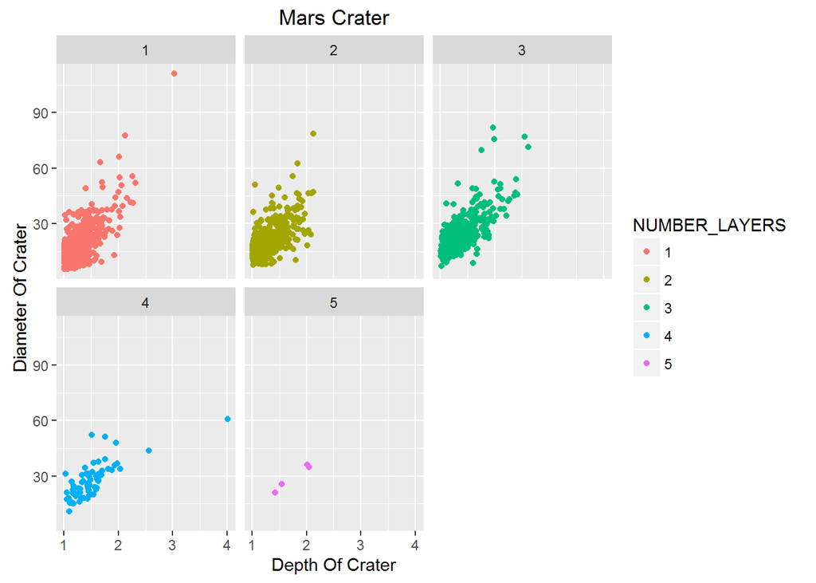

```r
craterbyfacetplot <- ggplot(marscrater.datastudy, aes(x = DEPTH_RIMFLOOR_TOPOG, y = DIAM_CIRCLE_IMAGE))
craterbyfacetplot + geom_point(aes(color = NUMBER_LAYERS)) + facet_wrap(~NUMBER_LAYERS,
    labeller = "label_value") + labs(x = "Depth Of Crater", y = "Diameter Of Crater") +
    ggtitle("Mars Crater")
```

### Plotting a BoxPlot

#### Box Plot with ggplot

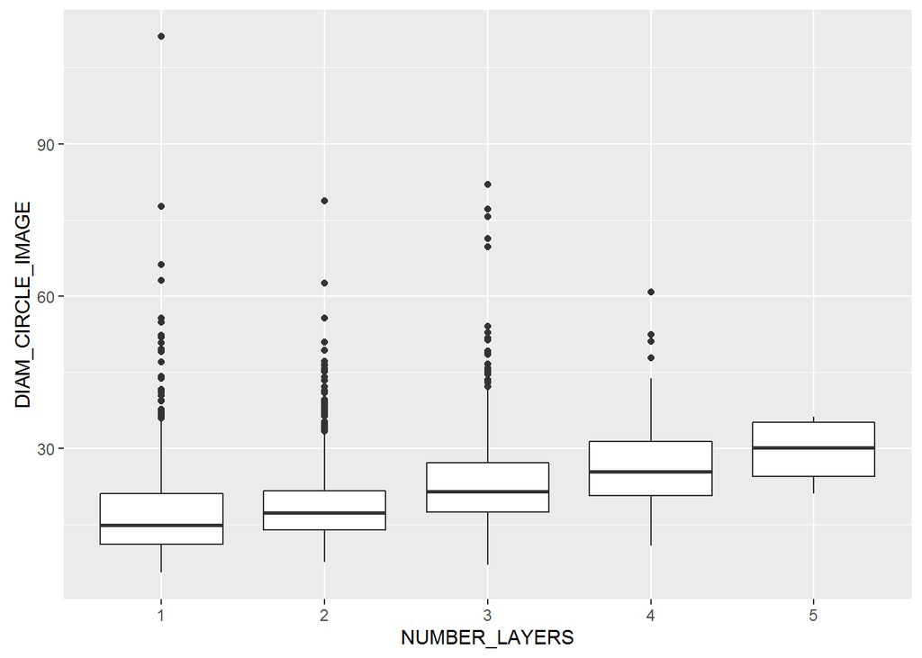

```r
ggplot(marscrater.datastudy, aes(x = NUMBER_LAYERS, y = DIAM_CIRCLE_IMAGE)) + geom_boxplot()
```

#### Box Plot with base package

The colors area for the box plots are repeated cyclically

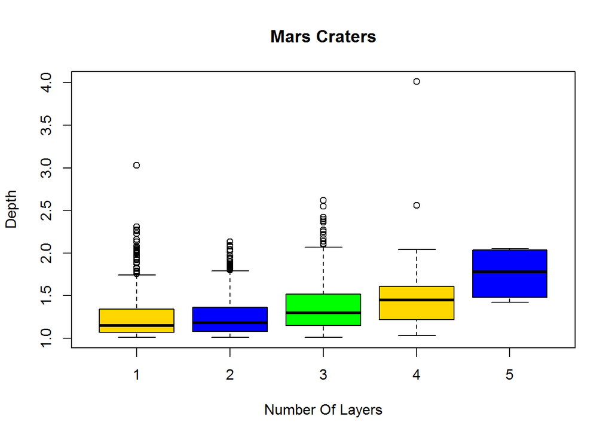

```r
boxplot(DEPTH_RIMFLOOR_TOPOG ~ NUMBER_LAYERS, data = marscrater.datastudy, notch = FALSE,
    col = (c("gold", "blue", "green")), main = "Mars Craters", xlab = "Number Of Layers",
    ylab = "Depth")
```

Creating notched boxplots

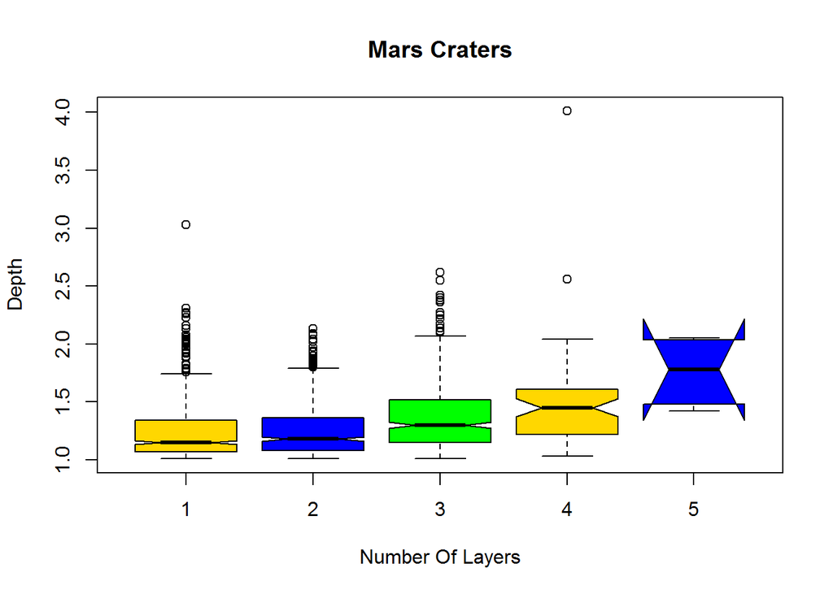

```r
boxplot(DEPTH_RIMFLOOR_TOPOG ~ NUMBER_LAYERS, data = marscrater.datastudy, notch = TRUE,
    col = (c("gold", "blue", "green")), main = "Mars Craters", xlab = "Number Of Layers",
    ylab = "Depth")
```

### Spooling the graphical output to desired file format

The following code allows the plots to be spooled to a file of desired format. Here it is spooled to PDF format.

```r
sink("MarsCraterPlots", append = TRUE, split = TRUE)
cat("Plots for Mars Crater Data ")
pdf("F:\\MarsCraterPlots_PDF.pdf")

ggplot(marscrater.datastudy, aes(x = NUMBER_LAYERS, y = DIAM_CIRCLE_IMAGE)) + geom_boxplot()

jpeg("F:\\MarsCraterPlots_JPEG.jpeg")
marscrater.datastudy$DIAM_CIRCLE_IMAGE <- as.numeric(marscrater.datastudy$DIAM_CIRCLE_IMAGE)

hist(x = marscrater.datastudy$DIAM_CIRCLE_IMAGE, xlab = "Histogram of Mars Crater Diameter")
dev.off()
```